# index

## Python Geospatial Data Analysis - Guided Project - Boston Crime Data

#### Generate Base Map

Map of Boston

[interactive chart not shown]

#### Mark Crime Scenes

[interactive chart not shown]

From the map, we learn that the hot spots where crimes occurred are :

- South End
- Roxbury
- Dorchester

These are the regions where more officers should be posted so that they can respond quickly.

#### View Districts with Highest Crime Rates

[interactive chart not shown]

#### Medical Assistance Analysis

[interactive chart not shown]

From the map, we learn that the crimes where medical assistance was required occurred at :

- Dorchester Avenue
- Cambridge Street
- Commercial Street
- Tremont Street
- Washington Street
- B Street
- Higher Street
- Storrow Drive
- Westland Aveneue
- Harrison Avenue
- S. Boston Bypass Road
- Seaport Boulevard
- Townsend Street
- Columbia Road
- Geneva Avenue
- Adams Street

These are the regions where the police should be more vigilant and provisions should be made for ambulances to reach quicker.

#### Crimes Commited

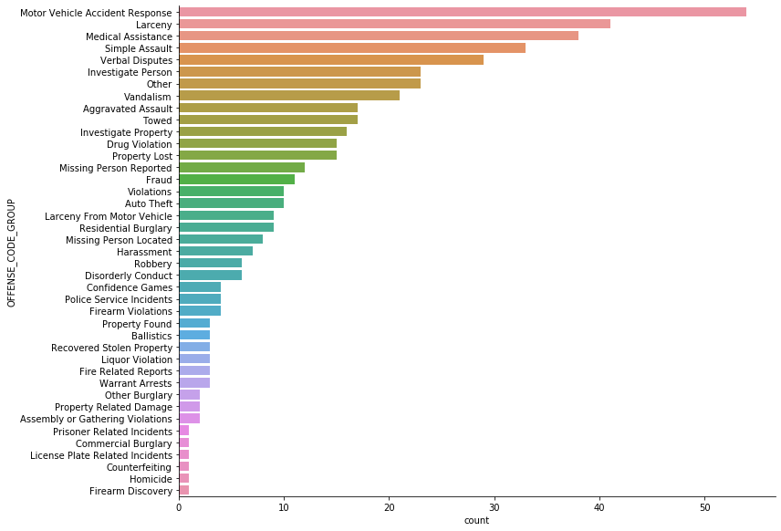

#### Motor Vehicle Accident Response

[interactive chart not shown]

If we study Medford Street, we find that it is close to Barry Playground. This means that some of the road accidents may have been caused due to parents who were possibly distracted by their children and could not focus on driving.There is a vine shop at the intersection of Moulton Street and Vine Street. It is possible that some of the accidents were DUI. The accident also hapens in the intersection so there are chances of accident while driving

#### Larceny

[interactive chart not shown]

If we study Faneuil Hall Square, we see that is is a commercial area with plenty of shops, markets, fast food restaurants etc. It is understandable why it is a hot spot for larceny.